# Practical Machine Learning Course_Project

## R Markdown

#### The goal of your project is to predict the manner in which they did the exercise. This is the “classe” variable in the training set. You may use any of the other variables to predict with. You should create a report describing how you built your model, how you used cross validation, what you think the expected out of sample error is, and why you made the choices you did. You will also use your prediction model to predict 20 different test cases.

### Background

#### Using devices such as Jawbone Up, Nike FuelBand, and Fitbit it is now possible to collect a large amount of data about personal activity relatively inexpensively. These type of devices are part of the quantified self movement - a group of enthusiasts who take measurements about themselves regularly to improve their health, to find patterns in their behavior, or because they are tech geeks. One thing that people regularly do is quantify how much of a particular activity they do, but they rarely quantify how well they do it. In this project, your goal will be to use data from accelerometers on the belt, forearm, arm, and dumbell of 6 participants. They were asked to perform barbell lifts correctly and incorrectly in 5 different ways. More information is available from the website here: http://web.archive.org/web/20161224072740/http:/groupware.les.inf.puc-rio.br/har (see the section on the Weight Lifting Exercise Dataset).

### Data

#### The training data for this project are available here:

#### https://d396qusza40orc.cloudfront.net/predmachlearn/pml-training.csv

#### The test data are available here:

#### https://d396qusza40orc.cloudfront.net/predmachlearn/pml-testing.csv

#### The data for this project come from this source: http://web.archive.org/web/20161224072740/http:/groupware.les.inf.puc-rio.br/har. If you use the document you create for this class for any purpose please cite them as they have been very generous in allowing their data to be used for this kind of assignment.

## Import required libraries and set a seed for repeatability

```r
library(caret)
library(knitr)
library(rattle)
```

```r
library(rpart.plot)
library(corrplot)
library(randomForest)
set.seed(42)
```

## Part I: Get and Clean the Data

### Download the data

```r
trnurl <- "https://d396qusza40orc.cloudfront.net/predmachlearn/pml-training.csv"
trn <- read.csv(url(trnurl),header=TRUE)

tsturl <- "https://d396qusza40orc.cloudfront.net/predmachlearn/pml-testing.csv"
tst <- read.csv(url(tsturl),header=TRUE)
```

### I partition the training data into a train and test set so that we still have a validation set (3 sets total)

```r
split <- createDataPartition(trn$classe, p=0.7, list=FALSE)
TrainSet <- trn[split, ]
TestSet  <- trn[-split, ]
```

### I remove variables that do not change much if at all (variance) since they will have little to no bearing on the model outcome.

```r
novar <- nearZeroVar(TrainSet)
TrainSet <- TrainSet[, -novar]
TestSet  <- TestSet[, -novar]
tst <- tst[, -novar]
dim(TrainSet)
```

```
## [1] 13737   104
```

### I remove variables are largely NA’s since they too will have little to no bearing on the model outcome and may make the model much worse.

```r
nans    <- sapply(TrainSet, function(x) mean(is.na(x))) > 0.95
TrainSet <- TrainSet[, nans==FALSE]
TestSet  <- TestSet[, nans==FALSE]
tst <- tst[, nans==FALSE]
dim(TrainSet)
```

```
## [1] 13737    59
```

### I remove variables that are not predictors. (columns 1 to 5)

```r
TrainSet <- TrainSet[, -(1:5)]
TestSet  <- TestSet[, -(1:5)]
tst <- tst[, -(1:5)]
dim(TrainSet)
```

```
## [1] 13737    54
```

### Check to see if any remaining variables are highly correlated.

### A few are, but I am not concerned because the majority are not.

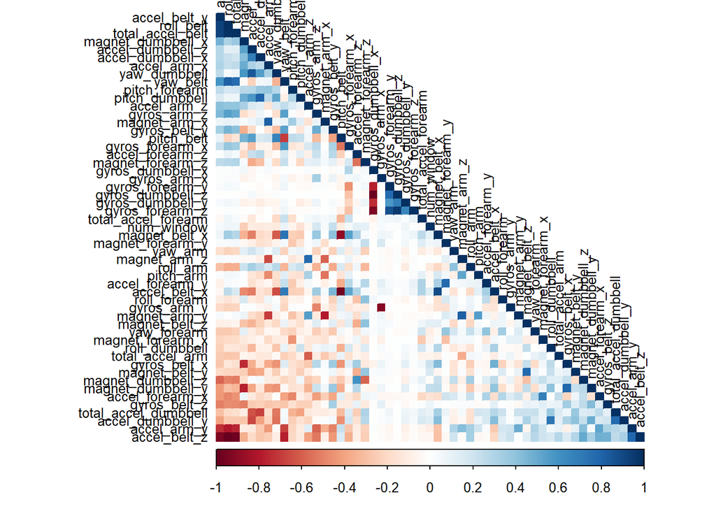

```r
corMatrix <- cor(TrainSet[, -54])
corrplot(corMatrix, order = "FPC", method = "color", type = "lower", tl.cex = 0.8, tl.col = rgb(0, 0, 0))
```

## Part II: Build Models

### Decision Tree

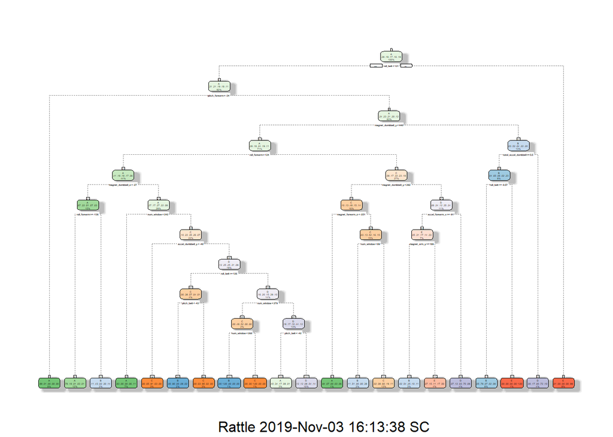

```r
df_fit <- rpart(classe ~ ., data=TrainSet, method="class")
fancyRpartPlot(df_fit)
```

```r
# prediction on Test dataset
pred_dt <- predict(df_fit, newdata=TestSet, type="class")
cm_dt <- confusionMatrix(pred_dt, TestSet$classe)
cm_dt
```

```
## Confusion Matrix and Statistics
##
##           Reference
## Prediction    A    B    C    D    E
##          A 1474  195   44   62   53
##          B   53  692   61   89  117
##          C   19   66  830  122   94
##          D  102  153   62  650  138
##          E   26   33   29   41  680
##
## Overall Statistics
##
##                Accuracy : 0.7351
##                  95% CI : (0.7236, 0.7463)
##     No Information Rate : 0.2845
##     P-Value [Acc > NIR] : < 2.2e-16
##
##                   Kappa : 0.6642
##
##  Mcnemar's Test P-Value : < 2.2e-16
##
## Statistics by Class:
##
##                      Class: A Class: B Class: C Class: D Class: E
## Sensitivity            0.8805   0.6076   0.8090   0.6743   0.6285
## Specificity            0.9159   0.9326   0.9381   0.9075   0.9731
## Pos Pred Value         0.8063   0.6838   0.7339   0.5882   0.8405
## Neg Pred Value         0.9507   0.9083   0.9588   0.9343   0.9208
## Prevalence             0.2845   0.1935   0.1743   0.1638   0.1839
## Detection Rate         0.2505   0.1176   0.1410   0.1105   0.1155
## Detection Prevalence   0.3106   0.1720   0.1922   0.1878   0.1375
## Balanced Accuracy      0.8982   0.7701   0.8735   0.7909   0.8008
```

```r
paste0("Decision Tree - Accuracy =", round(cm_dt$overall['Accuracy'], 4))
```

```
## [1] "Decision Tree - Accuracy =0.7351"
```

### Random Forest

#### Use the control to enforce cross validation

#### Because it is using cross validation, the resulting error (1-accuracy) is representative of out-of-sample error. The out-of-sample error is likely to be at or near 0.2%.

```r
ctrl_randomforest <- trainControl(method="cv", number=3, verboseIter=TRUE)
rf_fit <- train(classe ~ ., data=TrainSet, method="rf", trControl=ctrl_randomforest)
rf_fit$finalModel
```

```
##
## Call:
##  randomForest(x = x, y = y, mtry = param$mtry)
##                Type of random forest: classification
##                      Number of trees: 500
## No. of variables tried at each split: 27
##
##         OOB estimate of  error rate: 0.29%
## Confusion matrix:
##      A    B    C    D    E  class.error
## A 3905    0    0    0    1 0.0002560164
## B   10 2645    2    1    0 0.0048908954
## C    0    6 2390    0    0 0.0025041736
## D    0    0   13 2238    1 0.0062166963
## E    0    1    0    5 2519 0.0023762376
```

```r
pred_rf <- predict(rf_fit, newdata=TestSet)
cm_rf <- confusionMatrix(pred_rf, TestSet$classe)
cm_rf
```

```
## Confusion Matrix and Statistics
##
##           Reference
## Prediction    A    B    C    D    E
##          A 1674    2    0    0    0
##          B    0 1137    4    0    0
##          C    0    0 1022    4    0
##          D    0    0    0  960    0
##          E    0    0    0    0 1082
##
## Overall Statistics
##
##                Accuracy : 0.9983
##                  95% CI : (0.9969, 0.9992)
##     No Information Rate : 0.2845
##     P-Value [Acc > NIR] : < 2.2e-16
##
##                   Kappa : 0.9979
##
##  Mcnemar's Test P-Value : NA
##
## Statistics by Class:
##
##                      Class: A Class: B Class: C Class: D Class: E
## Sensitivity            1.0000   0.9982   0.9961   0.9959   1.0000
## Specificity            0.9995   0.9992   0.9992   1.0000   1.0000
## Pos Pred Value         0.9988   0.9965   0.9961   1.0000   1.0000
## Neg Pred Value         1.0000   0.9996   0.9992   0.9992   1.0000
## Prevalence             0.2845   0.1935   0.1743   0.1638   0.1839
## Detection Rate         0.2845   0.1932   0.1737   0.1631   0.1839
## Detection Prevalence   0.2848   0.1939   0.1743   0.1631   0.1839
## Balanced Accuracy      0.9998   0.9987   0.9976   0.9979   1.0000
```

```r
paste0("Random Forest - Accuracy =", round(cm_rf$overall['Accuracy'], 4))
```

```
## [1] "Random Forest - Accuracy =0.9983"
```

### Generalized Boosted Model

#### Use the control to enforce cross validation

```r
ctrl_gbm <- trainControl(method = "repeatedcv", number = 5, repeats = 1)
gbm_fit  <- train(classe ~ ., data=TrainSet, method = "gbm",
                    trControl = ctrl_gbm , verbose = FALSE)
gbm_fit$finalModel
```

```
## A gradient boosted model with multinomial loss function.
## 150 iterations were performed.
## There were 53 predictors of which 52 had non-zero influence.
```

```r
pred_gbm <- predict(gbm_fit, newdata=TestSet)
cm_gbm <- confusionMatrix(pred_gbm, TestSet$classe)
cm_gbm
```

```
## Confusion Matrix and Statistics
##
##           Reference
## Prediction    A    B    C    D    E
##          A 1669   22    0    0    1
##          B    4 1111    6    2    4
##          C    0    6 1015   12    4
##          D    1    0    4  950   13
##          E    0    0    1    0 1060
##
## Overall Statistics
##
##                Accuracy : 0.9864
##                  95% CI : (0.9831, 0.9892)
##     No Information Rate : 0.2845
##     P-Value [Acc > NIR] : < 2.2e-16
##
##                   Kappa : 0.9828
##
##  Mcnemar's Test P-Value : NA
##
## Statistics by Class:
##
##                      Class: A Class: B Class: C Class: D Class: E
## Sensitivity            0.9970   0.9754   0.9893   0.9855   0.9797
## Specificity            0.9945   0.9966   0.9955   0.9963   0.9998
## Pos Pred Value         0.9864   0.9858   0.9788   0.9814   0.9991
## Neg Pred Value         0.9988   0.9941   0.9977   0.9972   0.9954
## Prevalence             0.2845   0.1935   0.1743   0.1638   0.1839
## Detection Rate         0.2836   0.1888   0.1725   0.1614   0.1801
## Detection Prevalence   0.2875   0.1915   0.1762   0.1645   0.1803
## Balanced Accuracy      0.9958   0.9860   0.9924   0.9909   0.9897
```

```r
paste0("Generalized Boosted Model - Accuracy =", round(cm_gbm$overall['Accuracy'], 4))
```

```
## [1] "Generalized Boosted Model - Accuracy =0.9864"
```

## Part III: Choose Resulting Model

#### I then used the model to predict the category that all test values fall into for the quiz:

```r
predict_tst <- predict(rf_fit, newdata=tst)
predict_tst
```

```
##  [1] B A B A A E D B A A B C B A E E A B B B
## Levels: A B C D E
```